# Advanced R: Reshaping, merging, and data mainpulation - exercises

Richard Paquin Morel and Ali Ehlen, adapted from exercises by Christina Maimone

2021-09-14

## Load the data

Read both California energy datasets. Make sure the `datetime` variable is in an appropriate data type (i.e. not character).

### Answer

**`dplyr`**

```r
library(dplyr)
library(lubridate)
generation_dp <- read.csv(here::here("data/ca_energy_generation.csv"),
                          stringsAsFactors = F)
imports_dp <- read.csv(here::here("data/ca_energy_imports.csv"),
                       stringsAsFactors = F)

generation_dp <- mutate(generation_dp, datetime = as_datetime(datetime))
imports_dp <- mutate(imports_dp, datetime = as_datetime(datetime))
```

**`data.table`**

```r
library(data.table)
library(lubridate)
generation_dt <- fread(here::here("data/ca_energy_generation.csv"))
imports_dt <- fread(here::here("data/ca_energy_imports.csv"))

generation_dt[,datetime := as_datetime(datetime)]
imports_dt[,datetime := as_datetime(datetime)]
```

## Merge and reshape the data

Merge the two datasets and then melt the resulting dataframe/datatable to make it tidy.

### Answer

**`dplyr`**

```r
# We chose to use dplyr::inner_join here to illustrate how this can be done in a single piped operation, but you can also use base::merge
library(reshape2)
long_ca_energy_dp <- generation_dp %>%
  inner_join(imports_dp, by = "datetime") %>%
  melt(id.vars = "datetime",
       variable.name = "source",
       value.name = "output")
```

**`data.table`**

```r
all_sources <- merge(generation_dt, imports_dt, by = "datetime")

long_ca_energy_dt <- melt.data.table(all_sources,
                          id.vars = "datetime",
                          variable.name = "source",
                          value.name = "output")

# another option: advanced join
long_ca_energy_dt <- melt.data.table(generation_dt[imports_dt, on = "datetime"],
                          id.vars = "datetime",
                          variable.name = "source",
                          value.name = "output")
```

## Creating new variables

Create a series of new variables:

1. `day`, which is the year-month-day, without the hour. The `lubridate` function `as_date` will do this.
2. `log_output`, which is the natural log of the output.
3. **Challenge**: `per_output`, which is the percent of daily output represented by each observation. You will need to use `group_by` and to create a new variable with the total output for the day. (Make sure to use `ungroup()` after this!)

Bonus: If you are using `dplyr`, try to do this all in one pipe!

### Answer

**`dplyr`**

```r
long_ca_energy_dp <- long_ca_energy_dp %>%
  mutate(day = as_date(datetime),
         log_output = log(output)) %>%
  group_by(day) %>%
  mutate(total_daily_output = sum(output, na.rm = T)) %>%
  ungroup() %>%
  mutate(per_output = output/total_daily_output)

# Check results
long_ca_energy_dp %>% select(day, log_output, per_output) %>% head()
```

```
## # A tibble: 6 x 3
##   day        log_output per_output
##   <date>          <dbl>      <dbl>
## 1 2019-09-03       5.48   0.000293
## 2 2019-09-03       5.48   0.000293
## 3 2019-09-03       5.48   0.000293
## 4 2019-09-03       5.48   0.000293
## 5 2019-09-03       5.47   0.000292
## 6 2019-09-03       5.47   0.000291
```

**`data.table`**

```r
long_ca_energy_dt[,day := as_date(datetime)]
long_ca_energy_dt[,log_output := log(output)]
long_ca_energy_dt[,per_output := output/sum(output, na.rm = TRUE), by = day]

# one command (stylistic/readability choice)
long_ca_energy_dt[,`:=`(day = as_date(datetime),
                        log_output = log(output),
                        per_output = output/sum(output, na.rm = TRUE)),
                  by = day]
```

## Summarizing and analyzing data

1. Which source has the greatest mean output by hour? (Hint: Use the `dplyr` verb `arrange(desc(variable))` to order the data frame so that the largest value of `variable` is first. Don’t use `desc` and it arranges in ascending order. The `data.table` function is `setorder`.) Which has the least?
2. Which source has the greatest mean output by day? Which has the least? (Do not include zero values.)
3. Which sources has the greatest variance in usage over the course of a dataset? Which has the least? (Do not include zero values.)

### Answer

#### 1. Which source has the greatest mean output by hour? Which has the least?

**`dplyr`**

```r
long_ca_energy_dp %>%
  group_by(source) %>%
  summarize(mean_hourly = mean(output, na.rm = T)) %>%
  arrange(desc(mean_hourly))
```

```
## # A tibble: 12 x 2
##    source      mean_hourly
##    <fct>             <dbl>
##  1 natural_gas    10634.
##  2 imports         6683.
##  3 solar           3930.
##  4 large_hydro     2968.
##  5 wind            2620.
##  6 nuclear         2254.
##  7 geothermal       965.
##  8 small_hydro      419.
##  9 biomass          374.
## 10 biogas           235.
## 11 coal               9.09
## 12 other              0
```

```r
long_ca_energy_dp %>%
  group_by(source) %>%
  summarize(mean_hourly = mean(output, na.rm = T)) %>%
  arrange(mean_hourly)
```

```
## # A tibble: 12 x 2
##    source      mean_hourly
##    <fct>             <dbl>
##  1 other              0
##  2 coal               9.09
##  3 biogas           235.
##  4 biomass          374.
##  5 small_hydro      419.
##  6 geothermal       965.
##  7 nuclear         2254.
##  8 wind            2620.
##  9 large_hydro     2968.
## 10 solar           3930.
## 11 imports         6683.
## 12 natural_gas    10634.
```

**`data.table`**

```r
mean_hrly <- long_ca_energy_dt[,.(mean_hourly = mean(output)), by = source]
mean_hrly[mean_hourly == max(mean_hourly) | mean_hourly == min(mean_hourly)]
```

```
##         source mean_hourly
## 1: natural_gas    10634.25
## 2:       other        0.00
```

```r
# another option
setorder(mean_hrly, -mean_hourly)
mean_hrly
```

```
##          source  mean_hourly
##  1: natural_gas 10634.254960
##  2:     imports  6682.663194
##  3:       solar  3930.446429
##  4: large_hydro  2968.263889
##  5:        wind  2619.791171
##  6:     nuclear  2253.677083
##  7:  geothermal   964.964782
##  8: small_hydro   419.438492
##  9:     biomass   374.343254
## 10:      biogas   234.685516
## 11:        coal     9.092758
## 12:       other     0.000000
```

```r
# another option: chained together, no new variable
long_ca_energy_dt[,.(mean_hourly = mean(output)), by = source][mean_hourly %in% c(max(mean_hourly), min(mean_hourly))]
```

```
##         source mean_hourly
## 1: natural_gas    10634.25
## 2:       other        0.00
```

#### 2. Which source has the greatest mean output by day? Which has the least? (Do not include zero values.)

**`dplyr`**

```r
long_ca_energy_dp %>%
  filter(output>0) %>%
  group_by(day, source) %>%
  summarize(mean_daily = mean(output, na.rm = T)) %>%
  arrange(desc(mean_daily))
```

```
## # A tibble: 77 x 3
## # Groups:   day [7]
##    day        source      mean_daily
##    <date>     <fct>            <dbl>
##  1 2019-09-05 natural_gas     15403.
##  2 2019-09-04 natural_gas     14928.
##  3 2019-09-03 natural_gas     13051.
##  4 2019-09-06 natural_gas     12786.
##  5 2019-09-07 natural_gas      7508.
##  6 2019-09-08 solar            7278.
##  7 2019-09-07 solar            7186.
##  8 2019-09-09 solar            7133.
##  9 2019-09-03 imports          7076.
## 10 2019-09-09 imports          7058.
## # ... with 67 more rows
```

```r
long_ca_energy_dp %>%
  filter(output>0) %>%
  group_by(day, source) %>%
  summarize(mean_daily = mean(output, na.rm = T)) %>%
  arrange(mean_daily)
```

```
## # A tibble: 77 x 3
## # Groups:   day [7]
##    day        source mean_daily
##    <date>     <fct>       <dbl>
##  1 2019-09-07 coal         6.57
##  2 2019-09-08 coal         7.24
##  3 2019-09-06 coal         8.89
##  4 2019-09-03 coal         8.99
##  5 2019-09-04 coal         9.13
##  6 2019-09-05 coal         9.5
##  7 2019-09-09 coal        13.3
##  8 2019-09-09 biogas     229.
##  9 2019-09-04 biogas     233.
## 10 2019-09-05 biogas     235.
## # ... with 67 more rows
```

**`data.table`**

```r
mean_dly <- long_ca_energy_dt[output > 0,.(mean_daily = mean(output)), by = .(source, day)]

mean_dly[mean_daily %in% c(max(mean_daily), min(mean_daily))]
```

```
##         source        day   mean_daily
## 1:        coal 2019-09-07     6.569444
## 2: natural_gas 2019-09-05 15403.371528
```

#### 3. Which sources has the greatest variance in usage over the course of a dataset? Which has the least? (Do not include zero values.)

**`dplyr`**

```r
long_ca_energy_dp %>%
  filter(output>0) %>%
  group_by(source) %>%
  summarize(sd_output = sd(output, na.rm = T)) %>%
  arrange(desc(sd_output))
```

```
## # A tibble: 11 x 2
##    source      sd_output
##    <fct>           <dbl>
##  1 natural_gas   5275.
##  2 solar         3941.
##  3 imports       1761.
##  4 wind          1291.
##  5 large_hydro   1054.
##  6 small_hydro     30.7
##  7 biomass         23.0
##  8 geothermal       8.54
##  9 nuclear          6.63
## 10 biogas           4.22
## 11 coal             2.72
```

```r
long_ca_energy_dp %>%
  filter(output>0) %>%
  group_by(source) %>%
  summarize(sd_output = sd(output, na.rm = T)) %>%
  arrange(sd_output)
```

```
## # A tibble: 11 x 2
##    source      sd_output
##    <fct>           <dbl>
##  1 coal             2.72
##  2 biogas           4.22
##  3 nuclear          6.63
##  4 geothermal       8.54
##  5 biomass         23.0
##  6 small_hydro     30.7
##  7 large_hydro   1054.
##  8 wind          1291.
##  9 imports       1761.
## 10 solar         3941.
## 11 natural_gas   5275.
```

**`data.table`**

```r
var_by_source <- long_ca_energy_dt[output > 0,.(sd_output = sd(output)), by = source]

var_by_source[sd_output %in% c(max(sd_output), min(sd_output))]
```

```
##         source   sd_output
## 1:        coal    2.723103
## 2: natural_gas 5275.136615
```

There are also other ways to find min and max values:

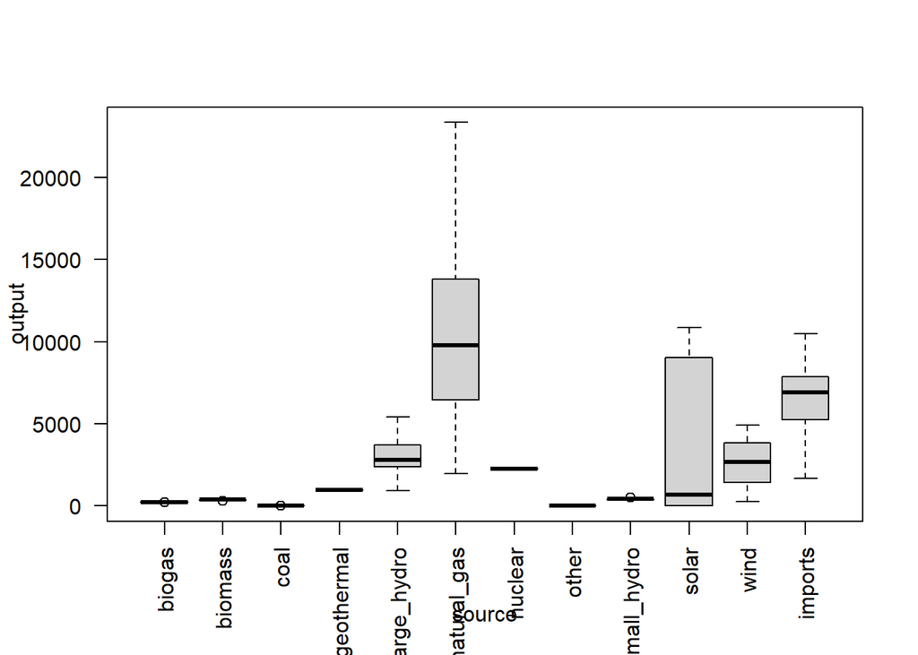

```r
boxplot(output ~ source, data = long_ca_energy_dt,las=2)
```

## Analyzing renewable versus non-renewable energy sources

The dataset `regroup.csv` has information about which sources are considered renewable by the state of California. Use this dataset, along with yourdata manipulation skills, to explore the use of renewable and non-renewable sources. Annotate what your descisions for the analysis.

Hint: Use your merge skills to merge the CA energy data with the `regroup` data. Which variable should you join by?